# Flight Dataset Analysis

## Data Wrangling

### What is/are the main feature(s) of interest in your dataset?

> I'm interested in figuring out what are best for predicting the flight is cancelled or not.

### What features in the dataset do you think will help support your investigation into your feature(s) of interest?

> I expect some numeric features will have a big impact on the final prediction like: `MONTH`, `week`, `DELAY` and `DISTANCE` and some categorical features like: `FL_DATE`

## Univariate Exploration

> In this section, we will investigate distributions of individual variables. we will start by looking at the distribution of the main variable of interest

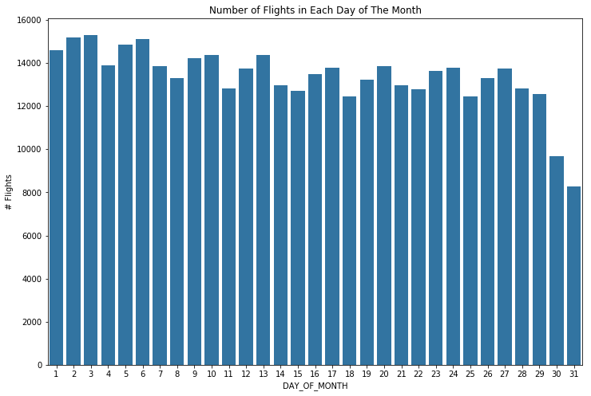

```python
plt.figure(figsize=(12,8))

color = sns.color_palette()[0]

sns.countplot(data=data, x='DAY_OF_MONTH', color=color)

plt.ylabel('# Flights')
plt.title('Number of Flights in Each Day of The Month');
```

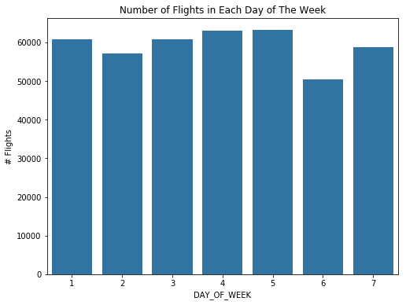

```python
plt.figure(figsize=(8,6))

color = sns.color_palette()[0]

sns.countplot(data=data, x='DAY_OF_WEEK', color=color)

plt.ylabel('# Flights')
plt.title('Number of Flights in Each Day of The Week');
```

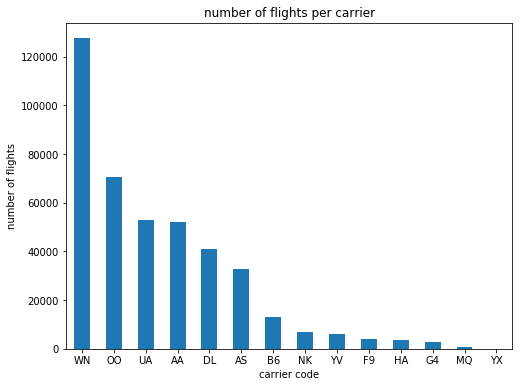

```python
plt.figure(figsize=(8, 6))

data.OP_UNIQUE_CARRIER.value_counts().plot(kind='bar')

plt.xlabel('carrier code');
plt.ylabel('number of flights');
plt.title('number of flights per carrier');
plt.xticks(rotation=0);
```

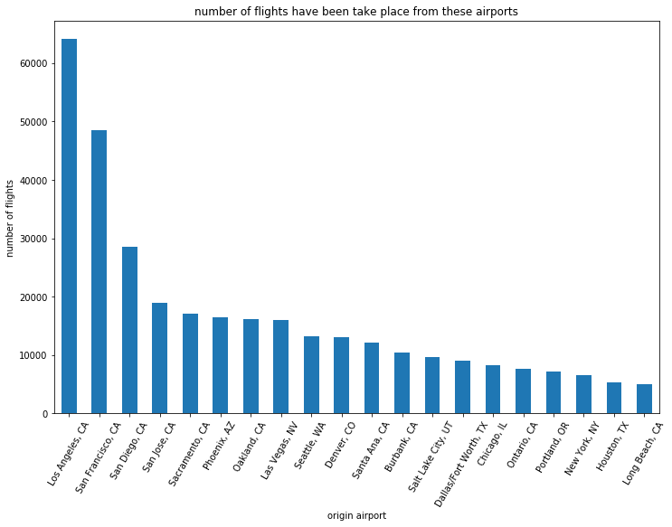

```python
plt.figure(figsize=(12,8))

# let's see the largest 20 airport
data.ORIGIN_CITY_NAME.value_counts()[:20].plot(kind='bar');

plt.xlabel('origin airport')
plt.ylabel('number of flights')
plt.title('number of flights have been take place from these airports')
plt.xticks(rotation=60);
```

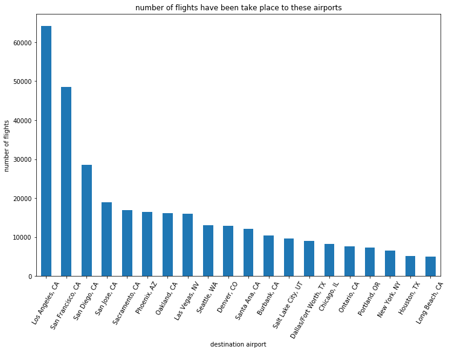

```python
plt.figure(figsize=(12,8))

# let's see the largest 20 airport
data.DEST_CITY_NAME.value_counts()[:20].plot(kind='bar');

plt.xlabel('destination airport')
plt.ylabel('number of flights')
plt.title('number of flights have been take place to these airports')
plt.xticks(rotation=60);
```

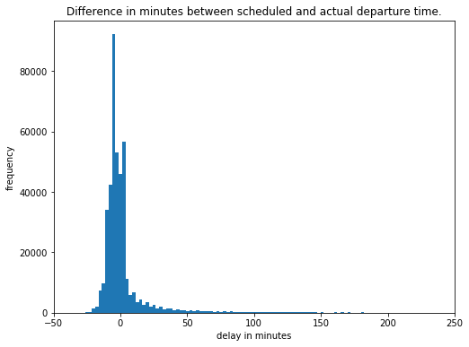

```python
plt.figure(figsize=(8,6))

plt.hist(data.DEP_DELAY, bins=1000);

plt.xlim(-50, 250)
plt.xlabel('delay in minutes')
plt.ylabel('frequency')
plt.title('Difference in minutes between scheduled and actual departure time.');
```

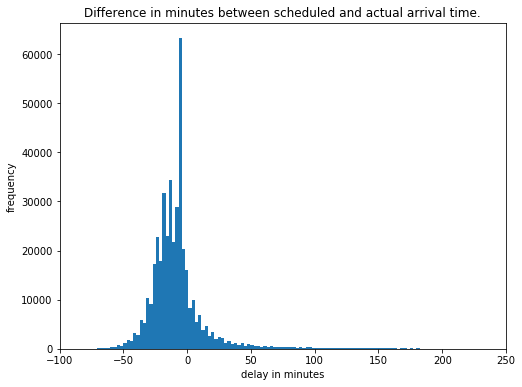

```python
plt.figure(figsize=(8,6))
plt.hist(data.ARR_DELAY, bins=1000);
plt.xlim(-100, 250)
plt.xlabel('delay in minutes')
plt.ylabel('frequency')
plt.title('Difference in minutes between scheduled and actual arrival time.');
```

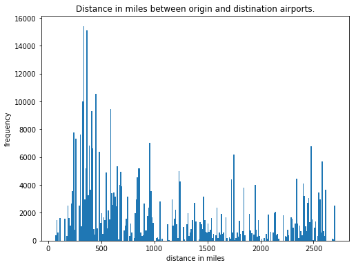

```python
plt.figure(figsize=(8,6))

plt.hist(data.DISTANCE, bins=250);

plt.xlabel('distance in miles')
plt.ylabel('frequency')
plt.title('Distance in miles between origin and distination airports.');
```

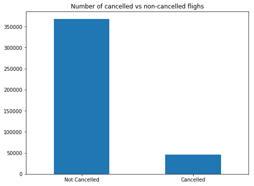

```python
fig, ax = plt.subplots(figsize=(8,6))

data.CANCELLED.value_counts().plot(kind='bar')

# change the xtick labels
ax.set_xticklabels(['Not Cancelled', 'Cancelled'], rotation=0)

plt.title('Number of cancelled vs non-cancelled flighs');
```

## Bivariate Exploration

> In this section, we will investigate relationships between pairs of variables in your data.

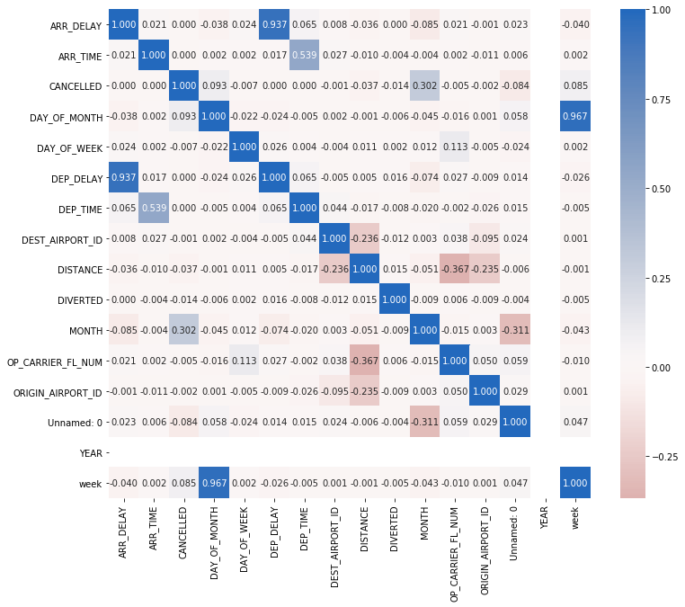

```python
plt.figure(figsize=(12,10))

sns.heatmap(data[numeric_cols].corr(), annot=True, fmt='.3f', cmap='vlag_r', center=0);
```

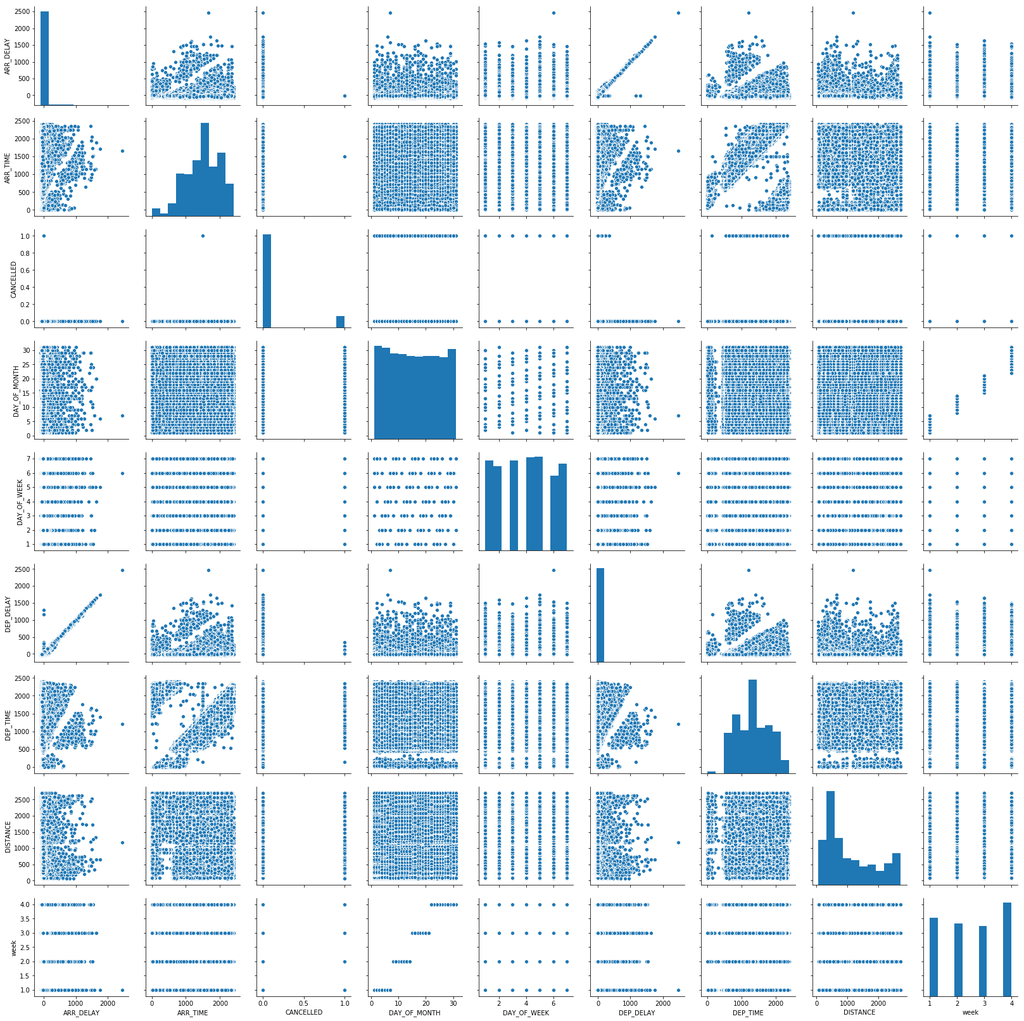

```python
sns.pairplot(data=data, vars=selected_cols);
```

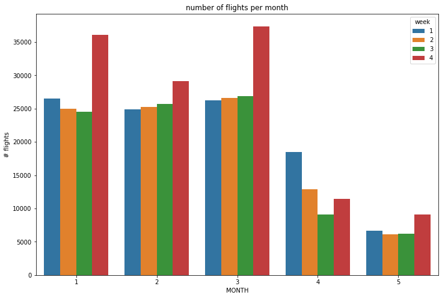

```python
plt.figure(figsize=(12,8))

sns.countplot(data=data, x='MONTH', hue='week')

plt.ylabel('# flights')
plt.title('number of flights per month');
```

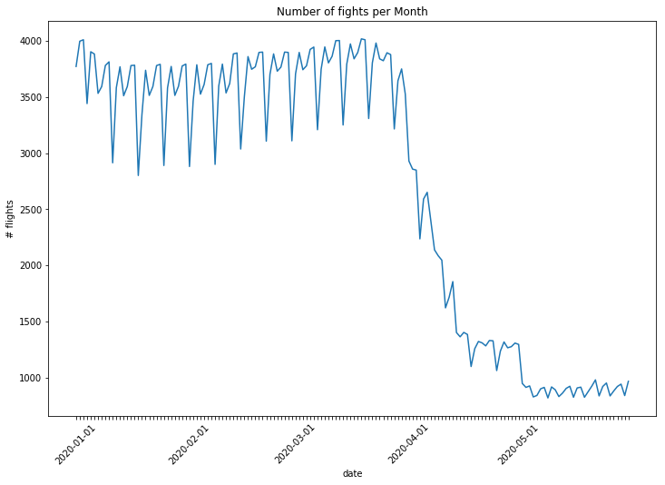

```python
fig, ax = plt.subplots(figsize=(12,8))

sns.lineplot(x=date_freq['date'], y=date_freq['frequency'])

# put a text label on the x-axis
plt.xticks(date_freq.index, date_freq['date'], rotation=45)

# write only the first day of each month on the x-axis
for i, date in enumerate(ax.xaxis.get_ticklabels()):
    if datetime.strptime(date.get_text(), '%Y-%m-%d').day != 1:
        date.set_visible(False)

plt.ylabel('# flights')
plt.title('Number of fights per Month');
```

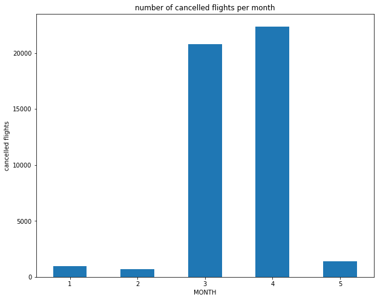

```python
plt.figure(figsize=(10,8))

data.groupby('MONTH')['CANCELLED'].sum().plot(kind='bar')

plt.xticks(rotation=0)

plt.ylabel('cancelled flights')
plt.title('number of cancelled flights per month');
```

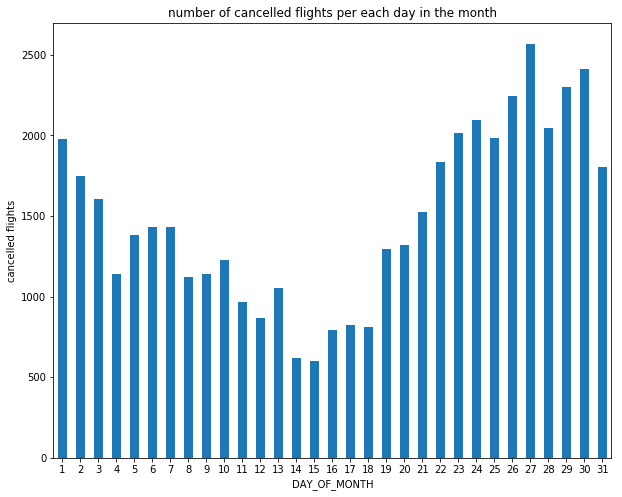

```python
plt.figure(figsize=(10,8))

data.groupby('DAY_OF_MONTH')['CANCELLED'].sum().plot(kind='bar')

plt.xticks(rotation=0)

plt.ylabel('cancelled flights')
plt.title('number of cancelled flights per each day in the month');
```

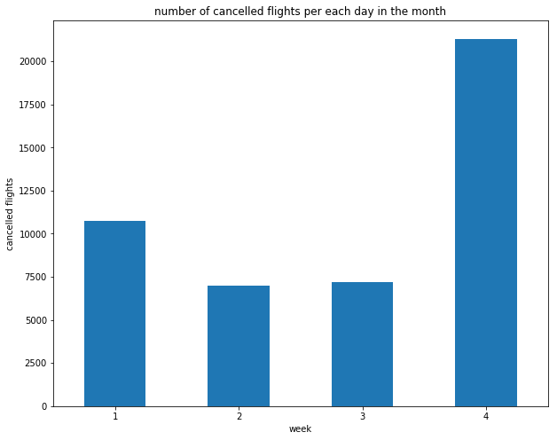

```python
plt.figure(figsize=(10,8))

data.groupby('week')['CANCELLED'].sum().plot(kind='bar')

plt.xticks(rotation=0)

plt.ylabel('cancelled flights')
plt.title('number of cancelled flights per each day in the month');
```

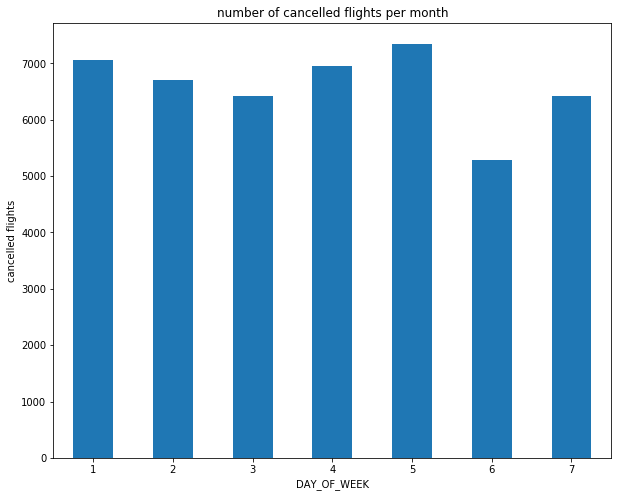

```python
plt.figure(figsize=(10,8))

data.groupby('DAY_OF_WEEK')['CANCELLED'].sum().plot(kind='bar')

plt.xticks(rotation=0)

plt.ylabel('cancelled flights')
plt.title('number of cancelled flights per month');
```

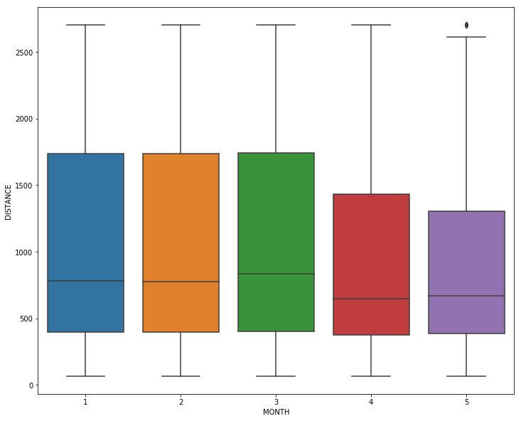

```python
plt.figure(figsize=(12,10))

sns.boxplot(data=data, x='MONTH', y='DISTANCE');
```

## Multivariate Exploration

> Here we want to create plots of three or more variables to investigate our data even further.

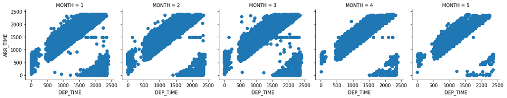

```python
fg = sns.FacetGrid(data=data, col='MONTH');
fg.map(plt.scatter, 'DEP_TIME', 'ARR_TIME');
```

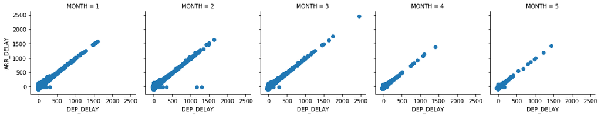

```python
fg = sns.FacetGrid(data=data, col='MONTH');
fg.map(plt.scatter, 'DEP_DELAY', 'ARR_DELAY');
```

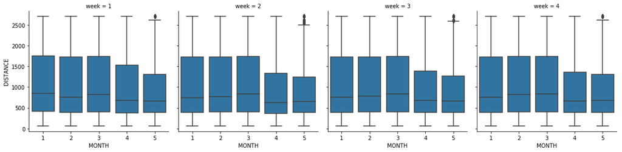

```python
fg = sns.FacetGrid(data=data, col='week', size=4);

fg.map(sns.boxplot, 'MONTH', 'DISTANCE');
```

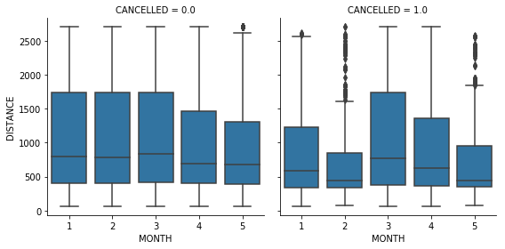

```python
fg = sns.FacetGrid(data=data, col='CANCELLED', size=4);

fg.map(sns.boxplot, 'MONTH', 'DISTANCE');
```

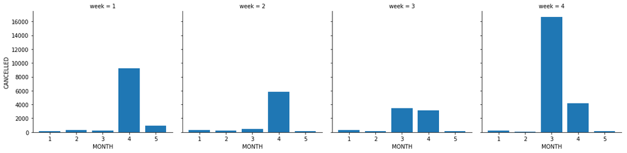

```python
cancelled_months = data.groupby(['MONTH', 'week'])['CANCELLED'].sum().reset_index()

fg = sns.FacetGrid(data=cancelled_months, col='week', size=4);

fg.map(plt.bar, 'MONTH', 'CANCELLED');
```